# Assignment Survival Data

# Project 1

# Analysis of binary data

### Read the Logistic.txt into R.

```r
data <- read.delim("Logistic.txt",header = TRUE, sep = "", dec = ".")
data$AIDS_no=data$n-data$AIDS_yes
head(data,2)
```

|  | AZT | AIDS_yes | n | AIDS_no |
| --- | --- | --- | --- | --- |
| 1 | Yes | 25 | 170 | 145 |
| 2 | No | 44 | 168 | 124 |

```r
n <- sum(data[,3]) #Number of patient #n
k <- sum(data[,2]) #Number of patients with AIDS #Sucesses #k
theta <- k/n #Probability that you have Aids
```

The data consist of patients being treated with AZT and the number of patients with AIDS, as well as patients not being treated with AZT and the number of patients having AIDS. It looks like more patients get AIDS if they are not treated with AZT.

### Fitting data to binomial distribution (i.e. consider all data as coming from the same population)

The log-likelihood of the binomial distribution is:
$$l(\theta)=\sum_{k=0}^{n}k\cdot log(\theta)+(n-k)\cdot log(1-\theta)+c(n,k)$$
where n is the number of patients, k is the number of patient with AIDS. Since it is considered as coming from the same population i.e. follow the same distribution, the data is fitted to one binomial distribution. The optimal value for theta is calculated below.

```r
#Formulating the likelihood function
binomial.log.likelihood = function(theta,success,size){
  -(sum(dbinom(x=success,size=size,prob=theta, log=TRUE)))}

#(theta.opt=optimize(binomial.log.likelihood, c(0.01,0.99),success=sum(data$AIDS_yes),size=sum(data$n))$minimum)

(nlminb(start=0.5,objective=binomial.log.likelihood,lower=0,success=k,size=n)$par)
```

```
[1] 0.204142
```

### Fit the Binomial separately to the two distributions and test if there is a difference between the groups.

The optimal values for theta in each model is calculated below.

```r
#Theta for patients treated with AZT. This is the probability of having AIDS when treated with AZT.
#(theta_AZT_yes.opt=optimize(binomial.log.likelihood, c(0.01,0.99),x=data$AIDS_yes[1],size=data$n[1])$minimum)

(theta_AZT_yes.opt=nlminb(start=0.5,binomial.log.likelihood,lower=0,success=data$AIDS_yes[1],size=data$n[1])$par)
```

```
[1] 0.1470588
```

```r
(theta_AZT_no.opt=nlminb(start=0.5,binomial.log.likelihood,lower=0,success=data$AIDS_yes[2],size=data$n[2])$par)
```

```
[1] 0.2619048
```

```r
#Theta for patients treated without AZT. This is the probability of having AIDS without treament.
#(theta_AZT_no.opt=optimize(binomial.log.likelihood, c(0.01,0.99),x=data$AIDS_yes[2],size=data$n[2])$minimum)
```

As expected, the probability for getting AIDS is lower when treated with AZT.

**Finding the confidence interval for the probabilities.**

```r
k1 <- data$AIDS_yes[1] #ATZ_yes
k2 <- data$AIDS_yes[2] #ATZ_no
n1 <- data$n[1]
n2 <- data$n[2]
p1 <- k1/n1
p2 <- k2/n2
p <- k/n
```

```r
library(numDeriv)
I <- hessian(binomial.log.likelihood,theta,success=k,size=n)
I_AZT_yes <- hessian(binomial.log.likelihood,theta_AZT_yes.opt,success=k1,size=n1)
I_AZT_no <- hessian(binomial.log.likelihood,theta_AZT_no.opt,success=k2,size=n2)

#The standard error
se <- 1/sqrt(I)
se_AZT_yes <- 1/sqrt(I_AZT_yes)
se_AZT_no <- 1/sqrt(I_AZT_no)



#confidence intervallet
(p+c(-1,1)*qnorm(0.975)*(p*(1-p))/sqrt(n))
```

```
[1] 0.1868216 0.2214624
```

```r
(p1+c(-1,1)*qnorm(0.975)*(p1*(1-p1))/sqrt(n1))
```

```
[1] 0.1282035 0.1659141
```

```r
(p2+c(-1,1)*qnorm(0.975)*(p2*(1-p2))/sqrt(n2))
```

```
[1] 0.2326734 0.2911361
```

```r
#(p+c(-1,1)*qnorm(0.975)*se/sqrt(n))
#(p1+c(-1,1)*qnorm(0.975)*se_AZT_yes/sqrt(n1))
#(p2+c(-1,1)*qnorm(0.975)*se_AZT_no/sqrt(n2))
```

**Test if there is a difference between the two grops**

The null hypothesis is that the two distributions are equal meaning that if AZT_yes follows $B(m,\pi_x)$ and AZT_no follows $B(n,\pi_y)$ $\pi_x=\pi_y$.

```r
x=data$AIDS_yes[1]
y=data$AIDS_no[1]
m=sum(data$AIDS_yes)
n=sum(data$AIDS_no)
N=m+n
t=x+y

#The standard test of equality of proportions is the famous chi-squared test
(chi.squared.test=N*(x*(n-y)-y*(m-x))^2/(m*n*t*(N-t)))
```

```
[1] 6.859695
```

```r
(pchisq(chi.squared.test, df=1, lower.tail=FALSE))
```

```
[1] 0.008816159
```

With a p-value of 0.008816159 we have strong evidence against the null hypothesis meaning that the two groups do not follow the same distribution.

The null hypothesis is $H_0: \theta=0$. Since $\theta$ is significantly different from zero, the null-hypothesis is rejected and it is concluded that the groups are significantly different from each other. This means that there is a difference in if a patient receives treament with AZT or not.

### Estimate parameters in the model (p0 probability of AIDS in control group, p1 probability of AIDS in treatment group) and report a confidence interval for the parameter describing the dif- ference, compare with the result above.

The parameters $\beta_0$ and $\beta_1$ can be estimated with the logistic regression model. Here $p_0$ denotes the probability of success (i.e. getting AIDS) in the control treatment and $p_1$ denotes the probability of succes in the new treatment.

$$p_{0}=\frac{e^{\beta_{0}}}{1+e^{\beta_{0}}}, \quad p_{1}=\frac{e^{\beta_{0}+\beta_{1}}}{1+e^{\beta_{0}+\beta_{1}}}$$
In the above $\beta_1$ describes the difference between the treatments. Thus if $\beta_1 = 0$ then there is no difference between the two treatments. The likelihood for the logistic regression can be written as:

$$L(\beta_0, \beta_1) = \Pi_i p_i^{y_i}(1-p_i)^{1-y_i}$$
Here $y_i$ is the succes in treatment i. We have that $i=0$ control treatment, $i=1$ test treatment. The log-likelighood is given as
$$logL(\beta_0, \beta_1) = \sum_i \left[(\beta_0 + \beta_1 \cdot treatment_i)y_i - log(1 + exp(\beta_0 + \beta_1 \cdot treatment_i)) \right]$$

```r
library(magrittr)
log_data = data

# Values as described on pp. 78
x=data$AIDS_yes[1]
y=data$AIDS_yes[2]
m=data$n[1]
n=data$n[2]
N=m+n
t=x+y
```

```r
# Example 4.4

x<- 25; m<- 170
y<- 44; n<- 168

that<- log(x/(m-x)*(n-y)/y)
se2<- 1/x + 1/(m-x) + 1/y + 1/(n-y)
se<- sqrt(se2)

ehat<- log(y/(n-y))
#print(c(that,ehat))
cat('theta-hat=',that,',  se=',se,'\n')
```

```
theta-hat= -0.721766 ,  se= 0.2787263
```

```r
# plots
par(mfrow=c(2,2))
th<- seq(-2,2,len=1000)
et<- seq(-2,0,len=1000)

fun1<- function(theta,eta){
  a <- exp(theta+eta)
  b<- exp(eta)
  x*theta + (x+y)*eta - m*log(1+a) - n*log(1+b)
}

ll<- outer(th,et,'fun1')
like<- exp(ll-max(ll))
contour(th,et,like,level=c(.1,.3,.5,.7,.9),
        xlab=expression(beta_0),
        ylab=expression(beta_1))
title(expression('Likelihood contour'))
```

```r
abline(v=that,h=ehat,lwd=.4)

lik1<- apply(like,1,max)
plot(th,lik1,type='n',xlab=expression(beta_0),
     ylab='Likelihood')
```

```r
lines(th,lik1)
abline(h=.15,lwd=.4)
```

```r
abline(v=0)
title(expression('Profile likelihood'))
```

[figure not shown]

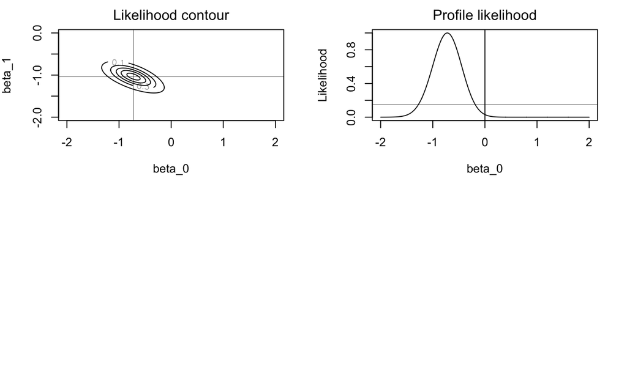

```r
# getting likelihood of H0
a<- approx(th,lik1,xout=0)$y
print(a)
```

```
[1] 0.03128901
```

```r
# getting likelihood interval
#a <- li(th,lik1,0.15)
#cat('95% CI for theta=',a,'\n')

# finding optimal parameters
fun2<- function(th){
  theta = th[1]
  eta = th[2]
  a <- exp(theta+eta)
  b <- exp(eta)
  -(x*theta + (x+y)*eta - m*log(1+a) - n*log(1+b))
}
opt <- nlminb(c(0, 0), fun2)
(opt$par)
```

```
[1] -0.721766 -1.036092
```

Again it is seen that the two groups are different, as b1 is statistically different from zero.

# Analysis of the survival time data

### Read the data act320.txt into R.

```r
#Load data
data.time <- read.delim("actg320.txt",header = TRUE, sep = "", dec = ".")
head(data.time,2)
```

|  | id | time | event | tx | sex | raceth | karnof | cd4 | age |
| --- | --- | --- | --- | --- | --- | --- | --- | --- | --- |
| 1 | 1 | 189 | 0 | 0 | 1 | 1 | 100 | 169.0 | 34 |
| 2 | 2 | 287 | 0 | 0 | 2 | 2 | 90 | 149.5 | 34 |

### How many patients got AIDS or dies in the two treatment groups?

### What is the proportion of patients that got AIDS or died in the two groups?

```r
#Count number of patient without treatment and without AIDS
(sum(data.time$tx == 0 & data.time$event == 0))
```

```
[1] 514
```

```r
#Count number of patient without treatment and AIDS
(sum(data.time$tx == 0 & data.time$event == 1))
```

```
[1] 63
```

```r
#Count number of patient with treatment and without AIDS
(sum(data.time$tx == 1 & data.time$event == 0))
```

```
[1] 541
```

```r
# Count number of patient with treatment and AIDS
(sum(data.time$tx == 1 & data.time$event == 1))
```

```
[1] 33
```

```r
#Calculating proportions

#No aids out of people without treatment
(sum(data.time$tx == 0 & data.time$event == 0))/sum(data.time$tx == 0)
```

```
[1] 0.8908146
```

```r
#Aids out of people without treatment
(sum(data.time$tx == 0 & data.time$event == 1))/sum(data.time$tx == 0)
```

```
[1] 0.1091854
```

```r
#No Aids out of people with treatment
(sum(data.time$tx == 1 & data.time$event == 0))/sum(data.time$tx == 1)
```

```
[1] 0.9425087
```

```r
#Aids out of people with treatment
(sum(data.time$tx == 1 & data.time$event == 1))/sum(data.time$tx == 1)
```

```
[1] 0.05749129
```

### Fit an exponential distribution to all the data.

The rate parameter and the likelihood is calculated.

```r
# Likelihood function for all patients with treat and without treatment. (event=1 is treatment). (pxep is used to define the probability after a certain point in time)
exp.likelihood=function(rate){
  -sum(dexp(x=data.time$time[data.time$event==1], rate=rate, log=TRUE))- sum(pexp(q=data.time$time[data.time$event==0], lower.tail = FALSE, rate=rate, log=TRUE))
  }


(nlminb(start=0.5,objective = exp.likelihood,lower=0)$par)
```

```
[1] 0.0003623448
```

```r
(nlminb(start=0.5,objective = exp.likelihood,lower=0)$objective)
```

```
[1] 856.5998
```

```r
#(optimize(exp.likelihood,c(0, 100),maximum=TRUE)$maximum)
```

**Fit an exponential distribution to each group.**

The parameters and the likelihoods are calculated.

```r
# Likelihood function for no treatment group. (p = cumulative function, d=density function)
exp.likelihood_no_treat=function(rate){
  -sum(dexp(x=data.time$time[data.time$event==1 & data.time$tx == 0], rate=rate, log=TRUE))- sum(pexp(q=data.time$time[data.time$event==0 & data.time$tx == 0], lower.tail = FALSE, rate=rate, log=TRUE))
}

(nlminb(start=0.5,objective = exp.likelihood_no_treat,lower=0)$par)
```

```
[1] 0.0004884062
```

```r
(nlminb(start=0.5,objective = exp.likelihood_no_treat,lower=0)$objective)
```

```
[1] 543.3349
```

```r
# Likelihood function for treatment group
exp.likelihood_with_treat=function(rate){
  -sum(dexp(x=data.time$time[data.time$event==1 & data.time$tx == 1], rate=rate, log=TRUE))- sum(pexp(q=data.time$time[data.time$event==0 & data.time$tx == 1], lower.tail = FALSE, rate=rate, log=TRUE))
}

(nlminb(start=0.5,objective = exp.likelihood_with_treat,lower=0)$par)
```

```
[1] 0.0002427363
```

```r
(nlminb(start=0.5,objective = exp.likelihood_with_treat,lower=0)$objective )
```

```
[1] 307.6767
```

It can be seen by looking at the objective values that the model fits the data better when the data is separated into the two treatment groups. (lower values is better, as it is a negative log likelihood function)

### Formulate a model where one parameter indicate the treatment effect

The following model is fitted to the data: $E[T]=e^{\beta_{0}+\beta_{1}}$

If $\beta{1}$ is significantly different from zero, it indicates that there is a difference between the control group and the treament group, meaning that ATZ does make a difference in regards to getting AIDS.

```r
# Implement negative log likelihood function

nll.exp <- function(rate){
  # Part for people with Aids
  val1 <- -sum(dexp(x=data.time$time[data.time$event==1],rate=exp(-rate[1]-rate[2]*data.time$tx[data.time$event==1]),log=TRUE))
  # Part for people without Aids
  val2 <- -sum(log(1-pexp(q=data.time$time[data.time$event==0],rate=exp(-rate[1]-rate[2]*data.time$tx[data.time$event==0]))))

  val1+val2
}
nll.exp(c(7,1))
```

```
[1] 868.2307
```

```r
# Find optimal rate:

opt.exp<- optim(c(7,1),nll.exp, hessian=T)

#opt.exp <- nlminb(start=c(0.001,0.005),objective=nll.exp,lower=c(-Inf,-Inf))
opt$par
```

```
[1] -0.721766 -1.036092
```

```r
opt.exp$hessian
```

[output not shown]

```r
# b1 -  is the treatment effect
(opt.exp$par[2])
```

```
[1] 0.6988937
```

### Making the Wald confidence interval

```r
#Making a confidence interval

HE <- hessian(nll.exp,opt.exp$par)
se <- sqrt(diag(solve(HE)))

#Confidence interval for b1
(opt.exp$par[2]+c(-1,1)*qnorm(0.975)*se[2])
```

```
[1] 0.2777464 1.1200410
```

It can be seen that the confidence interval does not cover zero which means that the two treatment groups are significantly different from each other. This is the same conclusion as in the previous question.

```r
nll.b1 <- function(rate,b1){

  val1 <- -sum(dexp(x=data.time$time[data.time$event==1],rate=rate[1]+b1*data.time$tx[data.time$event==1],log=TRUE))

  val2 <- -sum(pexp(q=data.time$time[data.time$event==0],rate=rate[1]+b1*data.time$tx[data.time$event==0],lower.tail=F,log=TRUE))

  val1+val2
}

profile.b1 <- function(b1){
  opt <- nlminb(start=c(0.001),objective=nll.exp,lower=c(-Inf),b1=b1)
  b0 <-opt$par

  -nll.b1(c(b0),b1)
}
```

```r
b1 <- seq(-0.0005,0.0005,0.00001)


n_b1 = length(b1)
p = rep(NaN,n_b1)

# for (i in 1:length(b1)) {
#    p[i] = exp(profile.b1(b1[i]))
#  }
#
# plot(b1,p/max(p),'l')

n_b1 = length(b1)
profile.b1.plot = rep(NaN,n_b1)
for (i in 1:length(b1)){
  profile.b1.plot[i] = profile.b1(b1[i])
}
```

```
Error in objective(.par, ...) : unused argument (b1 = -5e-04)
```

# Project 2